# ESM263 Assignment 3

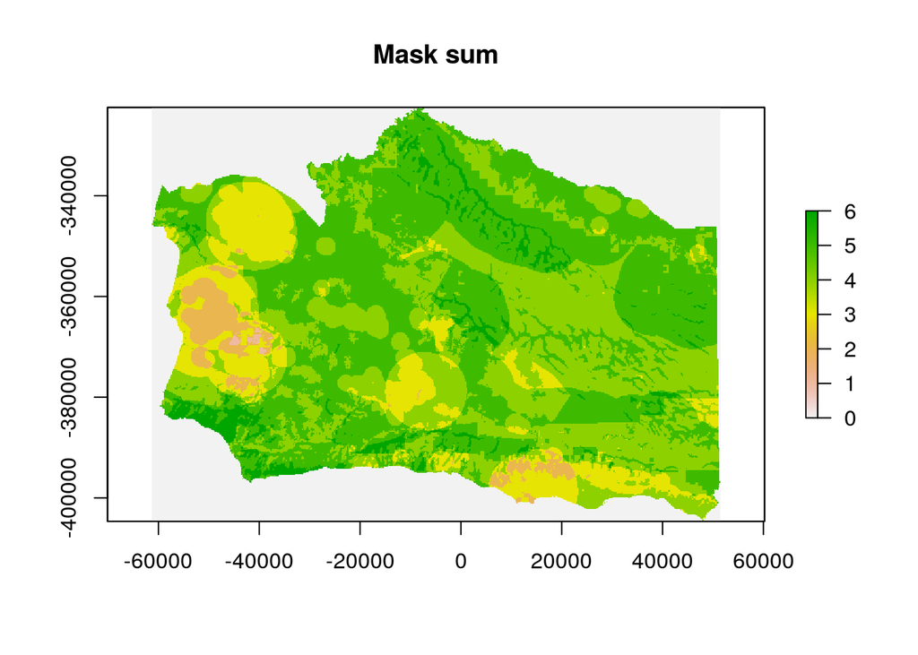

```r
writeRaster(mask_product, 'output/suitable_stack.tif', overwrite = TRUE)

mask_sum <- mask_stack %>%
  raster::calc(fun = sum, na.rm = TRUE)
plot(mask_sum, main = 'Mask sum', legend = TRUE)
```

Check it against ArcMap results:

```r
suitable_key <- raster('hw3_arc_outputs/suitable.tif')
check_rast(mask_product, suitable_key)
```

```
##    good diff_tot    celldiff cellcount
## 1 FALSE       49 0.007074791         0
```

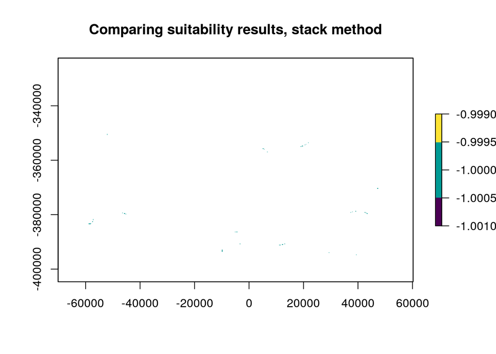

```r
plot_diffs(mask_product, suitable_key,
           title = 'Comparing suitability results, stack method',
           pal = 'Viridis')
```

## Analyzing the results

Now that we’ve found the suitable cells, we can use `raster::clump()` to do the same basic thing as the Region Groups tool in ArcMap, to “clump” together connected raster cells and give them distinct IDs. Let’s work with the `mask_product` results.

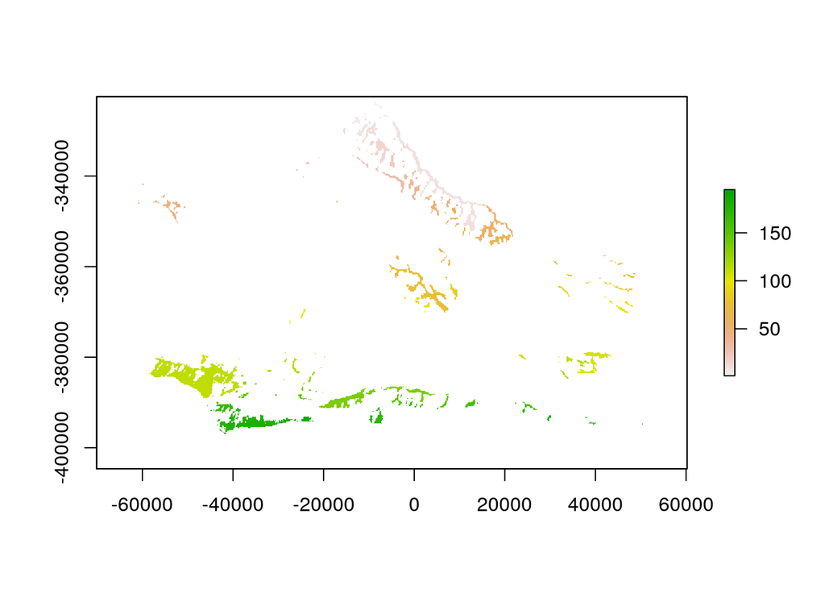

```r
results_clumped <- mask_product %>%
  raster::clump()
plot(results_clumped)
```

To identify the top ten sites by connected area, let’s use some `tidyverse` magic. Remembering that a raster can be considered as just a long vector of cell values, we can create a dataframe with the raster cell values, then aggregate and count ’em up to rank by size.

```r
top_ten_df <- data.frame(group_id = values(results_clumped)) %>%
  filter(!is.na(group_id)) %>%
  group_by(group_id) %>%
  summarize(cells = n(),
            hectares = cells * 4) %>%
  arrange(desc(cells)) %>%
  mutate(rank = 1:n()) %>%
  filter(rank <= 10)
```

Then we can substitute the rank values into the `results_clumped` raster, using the `raster::subs()` function to substitute raster values with new values from the `top_ten_df` data frame (kind of like `reclassify()`). Then use `ggplot()` to make a nicer map than the base `plot()` function.

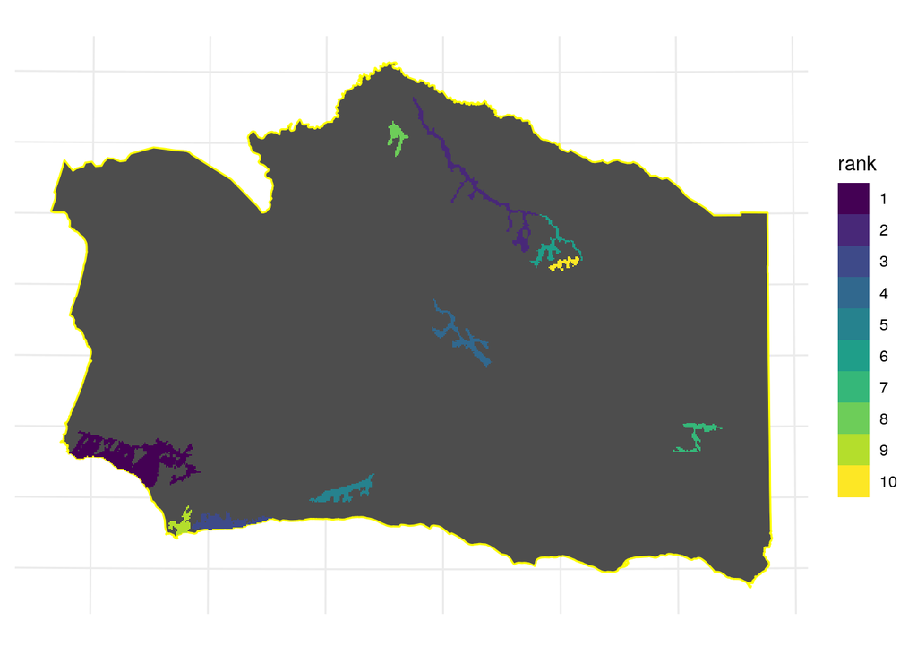

```r
results_ranked_rast <- raster::subs(results_clumped, top_ten_df,
                                    by = 'group_id', which = 'rank')

### ggplot can't work directly on rasters, it needs data.frames.  Let's
### also make the rank as a factor so it's categorical.
results_ranked_pts <- rasterToPoints(results_ranked_rast) %>%
  as.data.frame() %>%
  mutate(rank = factor(rank))

ggplot() +
  theme_minimal() +
  theme(axis.text = element_blank(),
        axis.title = element_blank()) +
  geom_sf(data = county_sf, fill = 'grey30', color = 'yellow') +
  geom_raster(data = results_ranked_pts, aes(x = x, y = y, fill = rank)) +
  scale_fill_viridis_d()
```

### Raster to polygons

We can also turn the ranked results into polygons, giving us more control over display in `ggplot`. `raster::rasterToPolygons()` turns it into an older spatial format, so we can coerce it into `sf` for easier use using the `st_as_sf()` function.

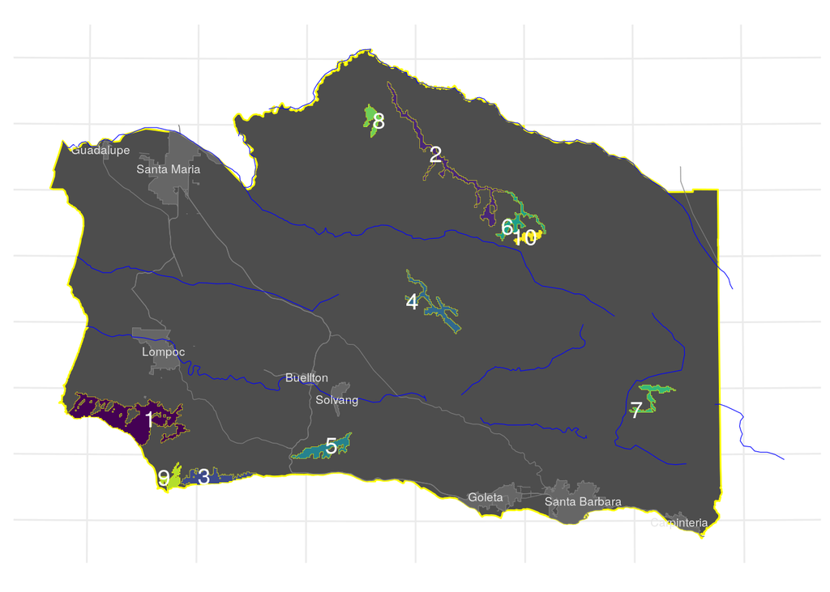

```r
results_ranked_poly <- rasterToPolygons(results_ranked_rast, dissolve = TRUE) %>%
  st_as_sf() %>%
  mutate(rank = factor(rank))

ggplot() +
  theme_minimal() +
  theme(axis.text = element_blank(),
        axis.title = element_blank()) +
  geom_sf(data = county_sf, fill = 'grey30', color = 'yellow') +
  geom_sf(data = roads_sf %>% filter(SPEED_LIM >= 45),
          color = 'grey50', size = .2) +
  geom_sf(data = cities_sf,
          color = 'grey50', fill = 'grey40', size = .2) +
  geom_sf(data = rivers_sf, color = 'blue', size = .2) +
  geom_sf(data = results_ranked_poly, aes(fill = rank),
          show.legend = FALSE,
          color = 'yellow', size = .1) +
  geom_sf_text(data = cities_sf, aes(label = CITY), color = 'grey90', size = 2.5) +
  geom_sf_text(data = results_ranked_poly, aes(label = rank), color = 'white', size = 5) +
  scale_fill_viridis_d()
```